# Project 1: Biomedical & Clinical Informatics

Merrimack College DSE6630: Healthcare & Life Sciences Analytics

Tim Souza & Chinonso Chilobe

20 May 2025

# 1 Introduction

We will pick up where we left off in Demo 1 to prepare you for analysis. Although this is not going to be as exhaustive as we would like to do if we were doing a complete project, our goal is to see this project go from **messy data** $\rightarrow$ **prediction & interpretation**. After all, we need to give something to the patient advocacy watchdog that they can deploy!

## 1.1 Our Analysis Plan

Our goal is to see this analysis through to generate a predictive model that the advocacy group can use, and hopefully it will be a decent one. To ensure that it stands the best chance of being a good predictive model, our analysis plan includes all the key steps in the data science life cycle/project flow, including: **cleaning**, **exploration**, **feature selection**, **pre-processing**, **unsupervised machine learning exploration**, and **supervised modeling**. Whew!

Our specific plan is to perform two big analyses in the hopes of having a nice deliverable to present to our client. The first will be a **segmentation analysis**, or clustering analysis, which will attempt to group our hospitals together on the basis of their attributes and their pneumonia-related readmissions. Thie will be done using a combination of PCA and $k$-means. Our second analysis will be to perform supervised, predictive analysis using an elastic net, which conveniently combines a penalized regression with variable selection so we can point our clients down a path of hospital attributes to focus on, as well as a model they can use to make future predictions.

## 1.2 Your objective.

Your object is to work through this Project 1. You will have 31 Questions to answer as you work through this, just as with Project 1. Then, you will be able to choose your own adventure again to perform your own **clinical informatics** analysis:

### Adventure 1.

**[Minimal coding, focus is on understanding cleaning, pre-processing, and the ML analyses we performed here.]** Choose ONE other condition (anything other than pneumonia) and run through the analyses again, using our same target variable. You will update your question, hypotheses, and predictions, but will be able to re-use all of the other code with very minor modifications. Credit will be based more on interpretation and not on coding. See more information on Adventure 1 here.

### Adventure 2.

**[More coding, but not as much, with a focus on the steps we’ve undertaken here and extending it to a new question & condition.]** Choose a slightly more complicated analysis to undertake, for example, focusing on surgical interventions (`HIP-KNEE` & `CABG`) or heart-related conditions (`HF`, `AMI`, & `CABG`). Coding should still be fairly minimal, but you are likely to run into problems with the code working exactly as-is, especially during cleaning. The advantage of this analysis is that it will be much more robust, have larger sample sizes, and would allow us to be able to say something far more informative to a subset of patients (e.g., those considering undergoing surgical interventions). See more information on Adventure 2 here.

### Adventure 3.

**[Most coding, but no cleaning or pre-processing, with an emphasis entirely on the machine learning analyses.]** Continue with the pneumonia-related data that you have here, completely cleaned and pre-processed, and do two more unsupervised OR supervised analyses. For example, you could do another kNN using the $k$ we identify in our Segmentation Analysis here, or you could do a random forest to account for any possible non-linearity. You could even choose to do a Ridge and LASSO regression and compare those analyses to what we get out of an Elastic Net. Any of these are fine, but you must **explain your decision** in your submission. See more information on Adventure 3 here.

## 1.3 A Fork in the Road!

This is the first of your choices in your adventure, and what you choose here could either lead to success or… **sudden death** (dum, dum, dummmm…). Choose wisely, young data scientists!

## Option 1.3.1

**Load data from the end of Demo 1, which includes the ordinal and frequency encoding you did (plus a little bonus cleaning to help).**

Load my version of the fully cleaned, encoded, & ready-to-proceed dataset from the end of Demo 1. These data are not yet ready for analysis (!) but we would be picking up with that here.

```r
## Uncomment if this is your choice:

load(here("FY2024_data_files/pneumoniaAnalyzeFullyEncoded2024.Rdata"))
dat2Analyze <- pneumoniaAnalyzeFullyEncoded
```

## Option 1.3.2

**Load data from Demo 1 without ANY encoding, but all other tidying the same.**

```r
## Comment out if this is NOT your choice:

## loading for later use.
load("FY2024_data_files/pneumoniaAnalyzeNoEncoding2024.Rdata")

##dat2Analyze <- pneumoniaAnalyzeNoEncoding
```

#### **Question 1**: [1 point]

Which dataset do you choose and why?

> Explain your selection here. Chosing the fully encoded datset since working on # 3 (further predictive models)

## 1.4 Helper code: Using `R` like an object-oriented language

Many of you still may be early enough in your programming journeys that you haven’t yet learned how to fully leverage the **objected-oriented** nature of programming languages like `Python`. `R` is not *technically* an object-oriented language in the same way, but we can hack it to function like one. That’s exactly what we are going to do here by loading a **helper function** directly from the `source` code.

We went through all the trouble in the Demo to perform encoding and now we get to use it! You will use the `source()` function to load a helper function that I have written, using my answer to the ordinal encoding question of the Demo, so that you can do all your **ordinal** encoding in a single line of code. Neat, huh?

**BUT WHY** are we doing the encoding now if we just chose to bring in non-encoded data? Because we can do **ordinal encoding** before or after data partitioning with impunity. It does not introduce data leakage to do so here, so we can do it in either order. This means that we can do it now simply for convenience.

**NOTE**: If you chose Option 1, the fully-encoded dataset, you can still run this chunk because there is a conditional in here that will not run your dataset since it is already encoded! But still make sure you understand the idea of `source` code because we will keep using it throughout the course!

```r
## This calls the code in the associated .R file
source(file = "doOrdinalEncoding.R")

## This checks to see if you loaded the already encoded dataset
if(!exists("pneumoniaAnalyzeFullyEncoded")) {
    ## This sets a list of PATTERNS to match for the columns to ordinal encode
    encodeList <- c("ComparedToNational_",
                    "PaymentCategory",
                    "ValueOfCareCategory",
                    "Score_Emergency department volume")

    ## This runs the function, which takes 3 arguments
    ## Open the source code to see what each argument does!
    dat2Analyze <- doOrdinalEncoding(df = dat2Analyze,
                                     encodeList = encodeList,
                                     quiet = FALSE)
}
```

# 2 Exploratory Data Analysis: Which of the possible target (outcome) variables should we use? (Continued)

**NOTE**: What follows is my (long-winded) answer to **Question 19** from the Demo.

### 2.1 Overview of our options

I am going to quickly break down the differences between the possible targets so we can make sure we really understand **what** they are measuring to allow us to make our most-informed selection of a target. Note: More information was found [in this PDF](https://qualitynet.cms.gov/files/5d0d3ae5764be766b0104c37?filename=Pneumo_ReadmMeasMethod.pdf). **This is really important for helping us choose the right one!**

Notice that I am also including a variable we didn’t look at previously called `ComparedToNational_Hospital return days for pneumonia patients`. This is because this is our best assessment of how the hospital is performing with regard to pneumonia readmissions relative to a national average. However, even though I’m including it in the table, I think it’s better to think of it as a **solid predictor**. It’s telling us how **length of stay (LOS)** in the hospital after pneumonia readmission stacks up compared to the national average. After a hospital readmission, it’s generally better to have *fewer* return days rather than more because it suggests better quality of care, more timely follow-up, and a greater chance of the patient recovering well at home. Since these are readmissions, having *more* days than average could also suggest that the hospital missed the severity or didn’t properly plan for the patient’s recovery at home and released them too early.

You may be wondering - could we use it as a target? Sure - but it’s not for the question we were posed by our stakeholder! Note that, if we did, we would need to perform a multinomial classification analysis. So, instead, let’s use this category to help us contextualize our hospitals as we choose between `Predicted`, `Observed`, and `Expected` readmission rates, as well as `Excess Readmission Ratio`.

Table 1. List of possible target variables from the pneumonia-related hospital readmission data. Which one to choose?

| Possible Target | Description |
| --- | --- |
| ComparedToNational_Hospital return days for pneumonia patients | Hospital return days measures the number of days patients spent back in the hospital (in the emergency department, under observation, or in an inpatient unit) within 30 days after they were first trea… |
| ExpectedReadmissionRate | The expected number of readmissions in each hospital is estimated using its patient mix and an average hospital-specific intercept. It is thus indirectly standardized to other hospitals with similar c… |
| PredictedReadmissionRate | The number of readmissions within 30 days predicted based on the hospital’s performance with its observed case mix. The predicted number of readmissions is estimated using a hospital-specific intercep… |
| ExcessReadmissionRatio | The ratio of the predicted readmission rate to the expected readmission rate, based on an average hospital with similar patients. Performance is compared against a ratio of one, such that below one is… |
| observed_readmission_rate | Our calculation of the observed number of pneumonia-related readmissions within 30 days found by dividing the number of readmissions observed for the hospital during the given period by the number of … |

### 2.2 Summary statistics of the possible targets

Now, I know I didn’t ask you to do it, but I will actually begin my assessment of which target is most appropriate by constructing a quick summary table. In my assessment of what is an appropriate target,

**Table 2. Possible target measure summaries**

| **Characteristic** | **N = 4,816**<sup>1</sup> |
| --- | --- |
| National Comparison Return Hospital Days |  |
| Better than average | 402 / 4,816 (8.3%) |
| Same as average | 2,285 / 4,816 (47%) |
| Worse than average | 827 / 4,816 (17%) |
| Unknown | 1,302 / 4,816 (27%) |
| Predicted Readmission Rate | 16.46 (1.93), 16.27 |
| (Missing) | 2,090 |
| Observed Readmission Rate | 17.1 (3.7), 16.9 |
| (Missing) | 2,603 |
| ExcessReadmissionRatio | 1.00 (0.06), 1.00 |
| (Missing) | 2,090 |
| Expected Readmission Rate | 16.43 (1.51), 16.39 |
| (Missing) | 2,090 |

<sup>1</sup> n / N (%); Mean (SD), Median

### 2.3 Comparing the four possible metrics to`ComparedToNational_Hospital return days for pneumonia patients`

Although `ComparedToNational_Hospital return days for pneumonia patients` is very compelling, it’s better as a **predictor** rather than a target because it gets at an aspect of hospital performance: once readmitted due to pneumonia, how long (as compared to the national average) are patients spending in the hospital? This means it makes a really nice predictor to use to *compare our four possible choices for pneumonia-related hospital readmissions*. We are looking for a clear separation in our ideal target between hospitals that have lower readmission rates AND also tend to do better than the national average at healing their readmitted patients!

So, this makes a really nice variable I could choose to **facet** plots, which means creating sub-plots that show up as panels. The thing is, if I know I want to **facet** plots, the first thing I have to do is reshape the data I want from *wide* into *long* format using, for example, the `pivot_longer()` function (the complement of `pivot_wider()` that we used in the Demo).

I don’t have to store it as a separate data frame (i.e., I can just pipe it directly into `ggplot()`!) but here I am choosing to so we can more easily make sure it’s reshaped correctly along the way. Thus, I am making a long-format version of the possible target variables called `longTargets` so that I can better decide which target to choose.

I mentioned `violin` and `density` plots specifically in Question 19 of Demo 1, as well as faceting. I am going to show you two ways to explore these data with these types of plots and you can decide which one(s) you find most informative here. You also may have thought of a better way to display the data too!

#### 2.3.1 Example with `geom_violin()`:

Here I am leaving the `NA` data (which I relabelled as `Unknown`) to get a sense for the degree of missingness.

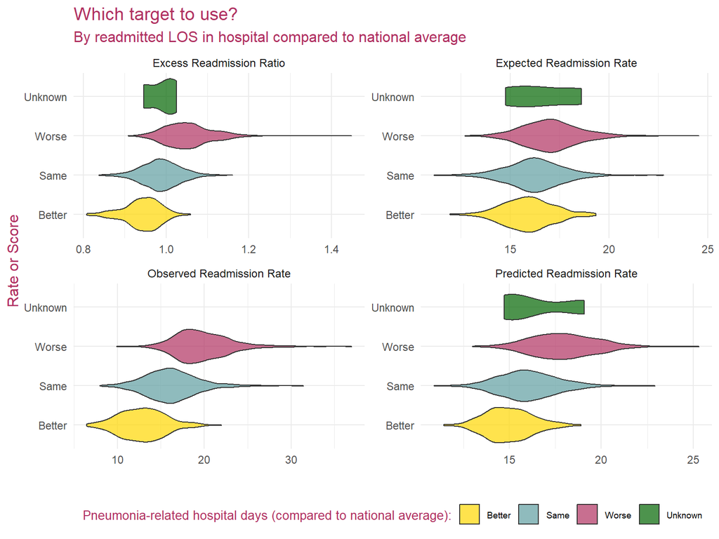

Figure 1. Readmission Rates vs. readmitted hospital LOS

#### **Question 2A**: [0.5 points]

If you have never encountered [violin plots](https://en.wikipedia.org/wiki/Violin_plot) before, they are honestly a wonderful way to assess the **symmetry** and **skew** of a distribution while more easily enabling comparisons between groups. They’re effectively a hybrid between a histogram and a boxplot, and we can even opt to overlay the boxplot quartiles in the plots as well, which is particularly handy!

**Your task** is to do just that by adding `geom_boxplot(width = 0.1)` (yes, just that one line!) in the appropriate place. Also change `include = FALSE` to `include = TRUE` in the R chunk header so that it shows up when you knit!

> Make sure to comment your line to call attention to it:

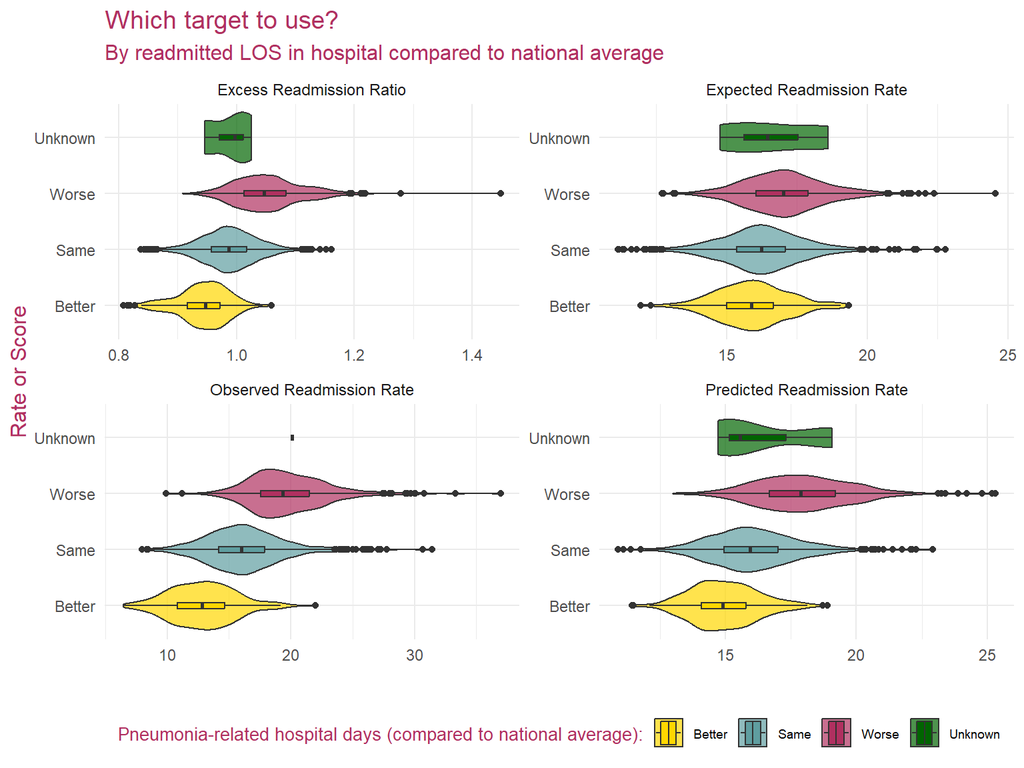

Figure 2. Readmission Rates vs. readmitted hospital LOS

#### **Question 2B**: [0.5 points]

Now that you can compare these groups more easily, what we’re looking for is a balance between **clear difference** between hospital ordinality relative to the national average (i.e., “Are better hospitals really better in pneumonia readmission rates?”).

Which target(s) appear the most distinct to you? > Your answer here. Based on the violin plots, I would choose Excess Readmission Ratio, since there is a good separation between ordinal categories related to the national average.

#### 2.3.2 Example with `geom_density()`:

We could also choose to overlay density plots instead of violin or boxplots, as this can sometimes help us see subtler separation of groups than we can see otherwise. This time, I am also going to ignore the “Unknown” (i.e., missing) class of hospitals to prevent things from getting too messy!

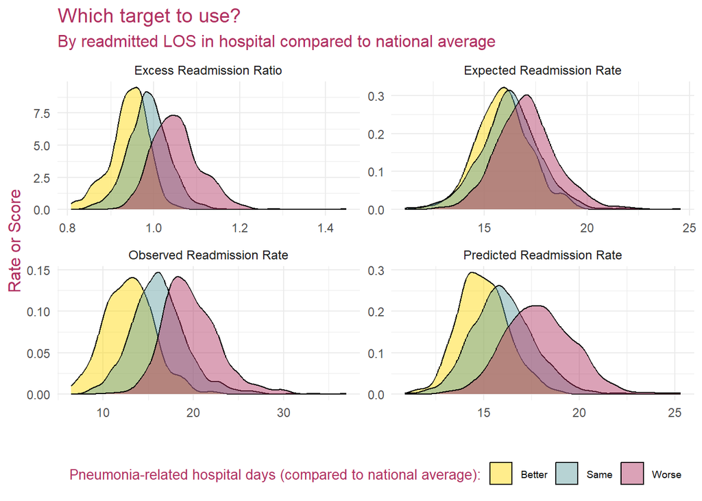

#### **Question 3**: [0.5 points]

> Your answer here. Yes, the density plot of Excess Readmission Ratio shows separation similar to the observed readmission rate.

### 2.4 What is the relationship of pneumonia-related hospital readmissions to the hospital performance metrics?

Something else we could do to help us make a decision is compare across predictors to look for the most striking relationships among the proposed target (readmission rate), how well compared to national average hospitals are performing AFTER readmitting pneumonia patients (how long after readmission they are in the hospital), and relationships among other hospital-performance predictors, like Medicaid spending or pneumonia-related deaths.

So, to do this, I’m going to make another long-format dataset and use this to make a bunch of faceted scatterplots where I put one of the readmission rates (let’s started with `Predicted Readmissions`) and look for strength in relationships. Note that doing it this way, through plotting, is a **heuristic way** of choosing a target variable and it isn’t the only way to do it!

#### **Question 4**: [1 point]

Change the **y-axis** out for _each of the four readmission rates. `Predicted Readmission Rates` has been started for you. Re-run the chunk and compare the results. **FOR FULL CREDIT** you must leave the graph on the choice you feel most strongly about AND update the title of the graph with which of the four possible readmission rates you chose. Explain below why you chose this one.

> Your answer here. I chose ExcessReadmission Ratio, since there seemed to be good separation in the ordinal levels.

**HINT 1**: What does higher medicare spending per patient tell you about the underlying population of a hospital?

**HINT 2**: Venous thrombolisms and deep vein thromboses (DVTs) are often “sneakier” conditions that have “silent” symptoms until the patient is in crisis. What would having higher scores at providing prophylaxis for these conditions potentially suggest about a hospital’s performance?

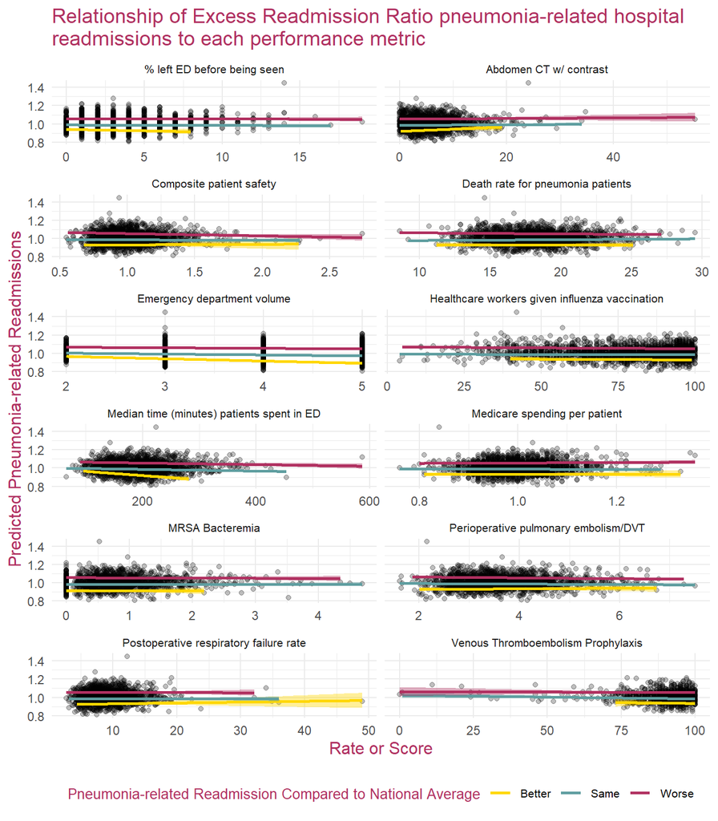

Figure 4. Readmission rate by hospital performance and readmitted patient LOS

**HINT 3**: Here’s how I would interpret the **relationship between PREDICTED pneumonia readmissions and pneumonia death rates, looking at whether hospitals performed better, same, or worse in terms of length-of-stay after readmission**. What I notice immediately is a moderate slope for hospitals with worse readmitted lengths of stay (LOS) [maroon line] compared to same [blue line] and especially better [yellow line]. This relationship is negative, implying that as the pneumonia-related death rate increases, readmissions **goes down**. Oh! So what this implies is that hospitals with higher deaths from pneumonia tend to have lower readmissions - and this is especially true for the ones who are have longer (worse than average) readmitted patient stays. In other words - these hospitals are __ probably releasing their pneumonia patients too soon from their first hospitalization__, leading to higher readmissions, longer readmitted stays, and even higher pneumonia-related deaths!

### 2.5 What is the relationship of pneumonia-related hospital readmissions to the patient satisfaction metrics?

Now let’s do a similar analysis but for the `HcahpsLinear...` variables. The **HCAHPS (Hospital Consumer Assessment of Healthcare Providers and Systems)** is a standardized survey that measures adult inpatient perceptions of hospital care. It’s a national, publicly reported survey mandated by the Centers for Medicare & Medicaid Services (CMS). Because it focuses on aspects of hospital care that are important to patients, it is often used to improve patient satisfaction and hospital quality.

#### **Question 5**: [1 point]

Again, you task is to change the **y-axis** out for _each of the four readmission rates. `Predicted Readmission Rates` has been started for you. Re-run the chunk and compare the results. **FOR FULL CREDIT** you must leave the graph on the choice you feel most strongly about AND update the title of the graph with which of the four possible readmission rates you chose. Explain below why you chose this one.

> Your answer here. I’m continuing with Excess Readmission Ratio to observe its performance with this dataset.

**HINT 1**: What does higher nurse and doctor communication mean for improved patient outcomes, including readmission?

**HINT 2**: Why might cleanliness not have much effect here even though pneumonia is a communicable disease?

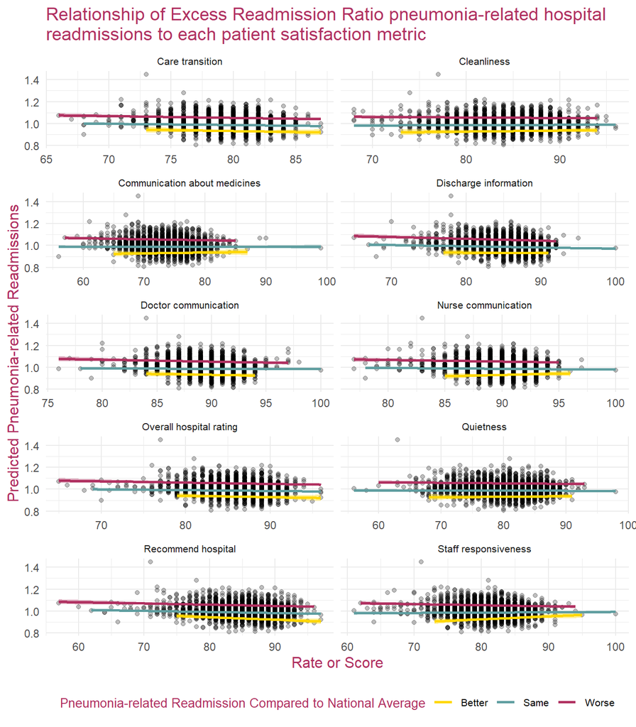

Figure 5. Readmission rate by patient satisfaction and readmitted patient LOS

**HINT 3**: Here’s how I would interpret the **relationship between PREDICTED pneumonia readmissions and overall hospital rating, looking at whether hospitals performed better, same, or worse in terms of length-of-stay after readmission**. What I notice immediately is a pretty substantial negative slope for hospitals with worse readmitted lengths of stay (LOS) [maroon line], moderate negative slope for hospitals with the same readmitted LOS [blue line], and slightly decreasing slope for hospitals with better readmitted LOS better [yellow line]. So what this implies is that hospitals with high ratings tend to have lower pneumonia-related readmissions, even among the hospitals with worse readmitted length-of-stays. This relationships is strongest when hospitals have longer LOS; maybe having a long readmission LOS stay **actually implies a form of quality**, like “Well, we got it wrong the first time, let’s make darn sure we get it right the second?” But hospitals that were already getting it pretty right don’t have as steep of slope because they were already doing well at readmissions to begin with, hence the almost flat line.

#### **Question 6**: [2 points]

What relationships do you find most compelling from these scatterplots and why? Also, name one outstanding question you have at this point, whether it is about the data, the data collection, or something more speculative.

> Your answer here. Interesting that the graphs for Doctor Communication and Overall recommend hospital have opposite trends.

Although there is certainly more EDA we could do, we are going to wrap that up here for the sake of moving on - but, as always, I encourage you to think about or even explore what else you would like to know about your data that we did not do!

### 2.5 Final remarks on target selection.

Going forward, I have selected `PredictedReadmissionRate` as our target. In a more thorough analysis, we would likely want to consider:

1. Circling back to our stakeholder to try to refine our question or target using domain knowledge
2. Perform experiments with our models to find the best predictive model since that is our ultimate goal.

However, given that we do not have the option or time for that, let me explain my choice. It’s the **best balance** of distinguishing hospitals with better and worse readmitted hospital stays, while still providing an **adjusted, hospital-specific** measure. Adjusted values will generally always be a better choice than the crude, even if our crude measure captures something interesting about the data, as it did here, or if it’s easier for our stakholder to comprehend. Our crude measure, `observed_readmission_rate` did the **best job** of recapitulating the readmitted hospital LOS (`ComparedToNational_Hospital return days for pneumonia patients`), but if that’s really our focus, wouldn’t it then be better to switch from a readmission rate to that as our target? Probably.

But remember that what matters most is that we are **matching our question**.

#### **Question 7**: [1 point]

Do you agree with my choice of target? Why or why not? (You are free to disagree!)

> I think it is an appropriate target that the stakeholder can relate to. Excess readmission ratio may be difficult for a stakeholder to grasp.

### 2.6 Bias and Limitation

#### **Question 8**: [2 points]

All studies have bias (introduced or systemic error) and limitations (failure to fully explain something). We could go more deeply into these concepts, but for now I want you to take a stab and just brainstorming either ways we might have bias OR the limitations of using this target variable. You do not need to answer both, but you’re welcome to do so. You can read more about bias [here](https://www.ncbi.nlm.nih.gov/books/NBK574513/) or see some deeper explanations of limitations [here](https://www.aje.com/arc/how-to-write-limitations-of-the-study/). You do not need to write a lot; just 2-3 sentences. I am simply asking you to pause and reflect on our choices here before we proceed.

> Your answer here. PredictedReadmissionRate may contain some bias, since it is based on rating each hospital on its historical case and patient mix performance. It is quite possible that current and future case and patient mix may differ.

# 3 Pre-processing and Feature Selection

The time has finally come to officially move **back** into pre-processing and feature selection so that we can finally build some models. I want you to take note of the order in which I’m doing things here; the flow can change from project to project, but generally it’s a good idea to get your dataset to a state of **manually curated features** before making your data partition.

## 3.1 Further feature selection and refinement.

### 3.1.1 Dropping the targets we aren’t planning to use. [Manual Method]

It’s time to say goodbye to the features we know would be far too redundant or non-informative given our target of `PredictedReadmissionRate`. We don’t need any of the `Sample_` columns, for example; these are merely sample sizes. Useful if we were doing standardization, but not necessary for us right now. We also are dropping the other possible target features that are too redundant with `PredictedReadmissionRate`.

#### **Question 9A**: [0.5 points]

Add your comments to the code as indicated to explain what I was doing at each of the steps.

> Your answer in the comments.

```r
dat2Analyze <- dat2Analyze %>%
  ## create a new dat2Analyze dataframe, remove the targets we have decided not to use (these are too highly correlated with PredictedReadmissionRate).
  select(-ExpectedReadmissionRate,
         -ExcessReadmissionRatio,
         -observed_readmission_rate,
         -contains(c("Sample_", "NumberOfPatients")),
         -NumberSurveysCompleted) %>%
  ## below renames some of the variables
  rename(`Median time (minutes) patients spent in ED` =
         `Score_Average (median) time patients spent in the emergency department before leaving from the visit A lower number of minutes is better`,
         `Composite patient safety` = `Score_CMS Medicare PSI 90: Patient safety and adverse events composite`,
         `ComparedToNational_Composite patient safety` = `ComparedToNational_CMS Medicare PSI 90: Patient safety and adverse events composite`) %>%
  ## select our chosen target of PredictedReadmissionRate, and everything else (not unselected earlier)
  select(PredictedReadmissionRate, everything())

## substitute Score_|HcahpsLinearMeanValue_|_Payment
colnames(dat2Analyze) <- gsub('Score_|HcahpsLinearMeanValue_|_Payment', '', colnames(dat2Analyze))
```

### 3.1.2 Dropping any features with near-zero variance. [Automated Method]

Next, we are going to take advantage of the `nearZeroVar()` function that is part of the `caret` package. We will drop any of the columns with near-zero variance. This is a way of automating (and thus standardizing) the process for choosing to drop non-informative columns due to zero or nearly zero variance.

#### **Question 9B**: [0.5 points]

If you are not familiar yet with the concept of **zero or near-zero variance**, do a little digging. Based on what you read, try to explain for your naive advocacy group stakeholders, why it’s important to remove the features with little variance.

> Your answer here. It is useful to remove features with low variance, since it reduces the dimensionality of the dataset, without losing much predictive power.

Table 3. Columns dropped due to near-zero variance.

| Variables Dropped |
| --- |
| PaymentCategory for pneumonia patients |
| ComparedToNational_Postoperative respiratory failure rate |
| ComparedToNational_Perioperative pulmonary embolism or deep vein thrombosis rate |

**Take note** of the number of features here.

#### **Question 9C**: [0.5 points]

You may or may not have noticed that I moved `FacilityID` to our rownames in the datasets you loaded today. Why did I choose to do that? Why do I want to make sure unique identifiers, like `FacilityID`, are out of the dataframe before I either (a) run `nearZeroVar()` or (b) proceed with the rest of the analysis?

> Your answer here. This is because unique identifiers will have a great amount of variance (due to being unique). FacilityID was moved to rownames, so it is not seen as an additional variable to be assessed for variability (it is simply a row identifier)

#### **Question 9D**: [1 point]

Do some research on, or lean into your previous knowledge, about the **curse of dimensionality** or the **big-P, little-N (n >> P) problem**. Using whatever you find or remember, can you justify why we likely do NOT have a **big-P, little-N (n >> P) problem** here? Make sure to explain.

> Your answer here. I don’t believe we have a big-p, litte-n problem, since we only have 30 variables, and we currently have 4816 observations.